# Holmusk Data Challange - RWD Drug Efficacy

Xingzhong (Jason) Jin

14 April, 2022

### Data sources

The following CSV files are provided:

- **Patient_characteristics.csv**: contains the information about socio-demographics of patients, diagnosis, lab values, and other existing therapies patients are on
- **Event_duration.csv**: Contains information about if the event happened to a patient or if patient was censored and the durations for each case from the start of therapy

### Analysis aim

The goal of the specific task is to compare the real-world efficacy of the two drugs by comparing the risk of events.

```r
# Common
library(here)
library(tidyverse)

# EDA
library(DataExplorer)

# PSM
library(MatchIt)
library(cobalt)

# Survival
library(survival)
library(survminer)
```

### EDA

#### Patient characteristics

Quick overview of dataset:

```r
DataExplorer::introduce(pt_char)
```

```
# A tibble: 1 × 9
   rows columns discrete_columns continuous_columns all_missing_columns
  <int>   <int>            <int>              <int>               <int>
1 19284      37               25                 12                   0
# … with 4 more variables: total_missing_values <int>, complete_rows <int>,
#   total_observations <int>, memory_usage <dbl>
```

```r
# Create a EDA report
# DataExplorer::create_report(pt_char,
#                             output_file = here("Report", "EDA_Patient_Characteristics.html"),
#                             report_title = "Patient Characteristics Data")
```

Check for missing values:

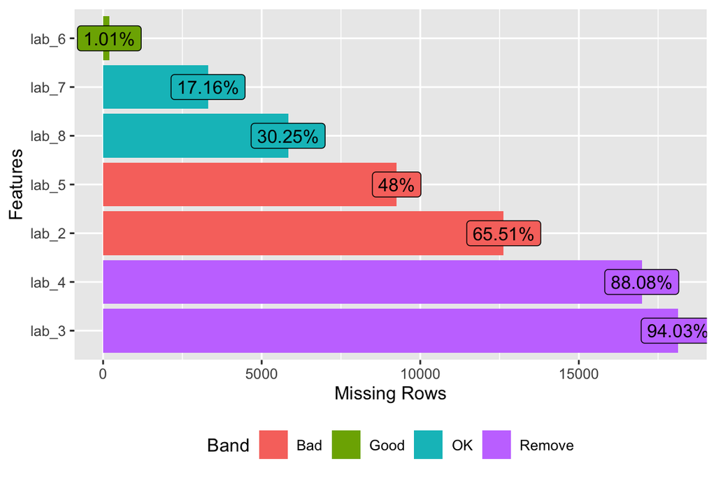

```r
DataExplorer::plot_missing(pt_char, missing_only = TRUE)
```

Check for Little’s MCAR test

```r
naniar::mcar_test(pt_char)
```

```
# A tibble: 1 × 4
  statistic    df p.value missing.patterns
      <dbl> <dbl>   <dbl>            <int>
1    28503.  2104       0               64
```

Check for duplicate patient_id (e.g. in case of hierarchical data):

```r
n_distinct(pt_char$patient_id)
```

```
[1] 19284
```

Check for variable independence and potential interactions

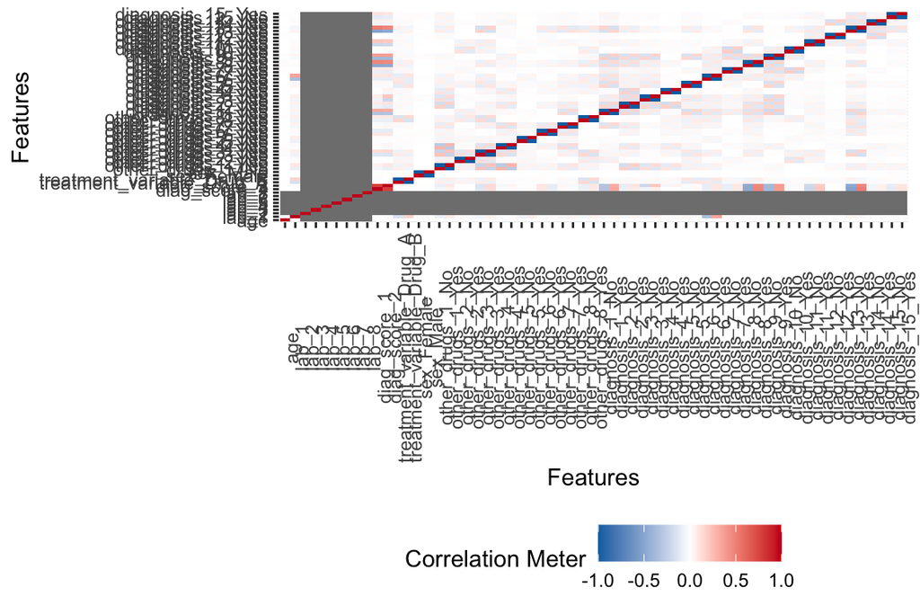

```r
pt_char %>%
  select(-patient_id) %>%
  DataExplorer::plot_correlation()
```

Check for baseline imbalance between two treatment groups.

```r
tableone::CreateTableOne(data = pt_char, strata = "treatment_variable",
                         vars = names(pt_char)[-c(1:2)]) %>%
  tableone::kableone() %>%
  kableExtra::remove_column(5) %>%
  kableExtra::kable_classic(lightable_options = "hover") %>%
  kableExtra::scroll_box(height = "450px")
```

|  | Drug_A | Drug_B | p |
| --- | --- | --- | --- |
| n | 8518 | 10766 |  |
| sex = Female (%) | 3478 (40.8) | 4420 (41.1) | 0.765 |
| age (mean (SD)) | 77.10 (10.90) | 77.04 (11.02) | 0.689 |
| other_drugs_1 = Yes (%) | 1828 (21.5) | 2889 (26.8) | <0.001 |
| other_drugs_2 = Yes (%) | 1104 (13.0) | 1742 (16.2) | <0.001 |
| other_drugs_3 = Yes (%) | 4110 (48.3) | 5974 (55.5) | <0.001 |
| other_drugs_4 = Yes (%) | 1536 (18.0) | 2041 (19.0) | 0.105 |
| other_drugs_5 = Yes (%) | 202 ( 2.4) | 289 ( 2.7) | 0.186 |
| other_drugs_6 = Yes (%) | 1203 (14.1) | 1462 (13.6) | 0.287 |
| other_drugs_7 = Yes (%) | 3076 (36.1) | 3630 (33.7) | 0.001 |
| other_drugs_8 = Yes (%) | 1536 (18.0) | 3336 (31.0) | <0.001 |
| diagnosis_1 = Yes (%) | 4710 (55.3) | 5714 (53.1) | 0.002 |
| diagnosis_2 = Yes (%) | 1693 (19.9) | 2385 (22.2) | <0.001 |
| diagnosis_3 = Yes (%) | 540 ( 6.3) | 824 ( 7.7) | <0.001 |
| diagnosis_4 = Yes (%) | 44 ( 0.5) | 113 ( 1.0) | <0.001 |
| diagnosis_5 = Yes (%) | 849 (10.0) | 531 ( 4.9) | <0.001 |
| diagnosis_6 = Yes (%) | 503 ( 5.9) | 1223 (11.4) | <0.001 |
| diagnosis_7 = Yes (%) | 1158 (13.6) | 1197 (11.1) | <0.001 |
| diagnosis_8 = Yes (%) | 3779 (44.4) | 5446 (50.6) | <0.001 |
| diagnosis_9 = Yes (%) | 3257 (38.2) | 3851 (35.8) | <0.001 |
| diagnosis_10 = Yes (%) | 1625 (19.1) | 2216 (20.6) | 0.010 |
| diagnosis_11 = Yes (%) | 403 ( 4.7) | 409 ( 3.8) | 0.002 |
| diagnosis_12 = Yes (%) | 206 ( 2.4) | 328 ( 3.0) | 0.009 |
| diagnosis_13 = Yes (%) | 2094 (24.6) | 2216 (20.6) | <0.001 |
| diagnosis_14 = Yes (%) | 591 ( 6.9) | 849 ( 7.9) | 0.014 |
| diagnosis_15 = Yes (%) | 117 ( 1.4) | 121 ( 1.1) | 0.135 |
| lab_1 (mean (SD)) | 0.92 (0.36) | 1.22 (1.18) | <0.001 |
| lab_2 (mean (SD)) | 347.41 (120.06) | 371.34 (134.79) | <0.001 |
| lab_3 (mean (SD)) | 128.59 (46.11) | 125.75 (46.66) | 0.303 |
| lab_4 (mean (SD)) | 6.20 (1.14) | 5.83 (0.98) | <0.001 |
| lab_5 (mean (SD)) | 6.11 (0.97) | 6.15 (1.11) | 0.095 |
| lab_6 (mean (SD)) | 22.21 (19.49) | 19.55 (8.51) | <0.001 |
| lab_7 (mean (SD)) | 1.16 (0.28) | 1.60 (0.77) | <0.001 |
| lab_8 (mean (SD)) | 111.36 (73.32) | 109.39 (71.72) | 0.115 |
| diag_score_1 (mean (SD)) | 2.58 (1.49) | 2.54 (1.54) | 0.053 |
| diag_score_2 (mean (SD)) | 3.52 (1.64) | 3.49 (1.71) | 0.216 |

#### Outcome Event

Quick overview of dataset:

```r
DataExplorer::introduce(event_time)
```

```
# A tibble: 1 × 9
   rows columns discrete_columns continuous_columns all_missing_columns
  <int>   <int>            <int>              <int>               <int>
1 19284       4                1                  3                   0
# … with 4 more variables: total_missing_values <int>, complete_rows <int>,
#   total_observations <int>, memory_usage <dbl>
```

Quick view on gross bleeding rate between two treatment groups over time:

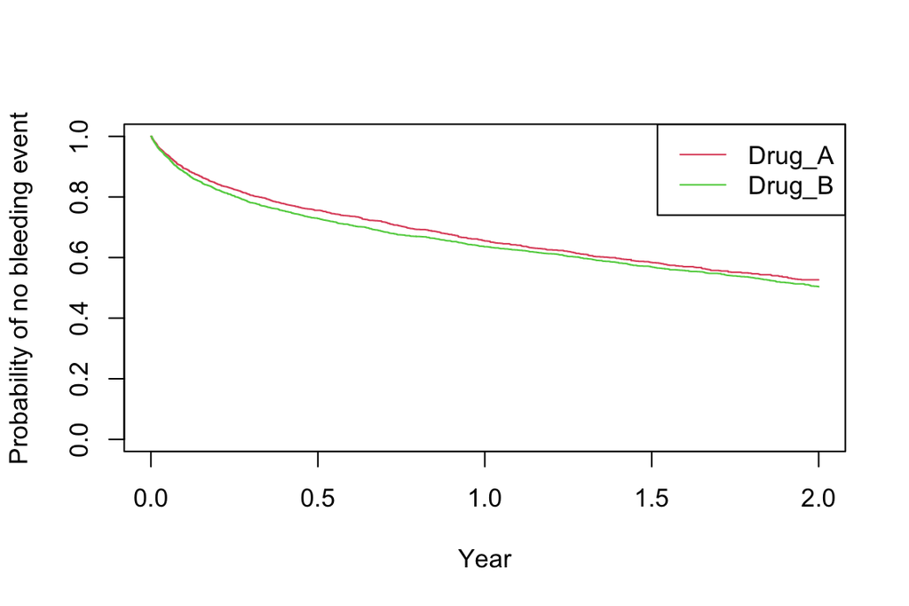

```r
surv_fit <-
  event_time %>%
  survfit(Surv(duration_in_years, bleeding_event_1_event_0_censored) ~ treatment_variable, data = .)

plot(surv_fit,
     xlab = "Year",
     ylab = "Probability of no bleeding event",
     col = 2:3)
legend("topright", levels(pt_char$treatment_variable), col = 2:3, lty = 1)
```

### Inference analysis

#### Propensity score matching

As there are lots of missing values in the “lab_value” variables, and missingness is not MCAR. Simple impuation is used to indicate missingness in PSM.

```r
set.seed(123)

# function to perform single simple imputation before PSM
simple_impute <- function(df) {

  getmode <- function(var) {
    uniqv <- unique(var)
    mode <- uniqv[which.max(tabulate(match(var, uniqv)))]

    return(mode)
  }

  # identify variable that needs to be imputed
  vars_to_impute <- df %>%
    DataExplorer::profile_missing() %>%
    dplyr::filter(num_missing > 0) %>%
    pull(feature) %>%
    as.character()


  df <- df %>%

    # single simple median imputation of missing continuous covariates for PSM matching
    mutate(across(where(is.numeric) & any_of(vars_to_impute), is.na, .names = "{.col}_na")) %>%
    mutate(across(where(is.numeric) & any_of(vars_to_impute), ~coalesce(.x, mean(.x, na.rm = TRUE)))) %>%

    # single simple median imputation of missing continuous covariates for PSM matching
    mutate(across(where(is.factor) & any_of(vars_to_impute), is.na, .names = "{.col}_na")) %>%
    mutate(across(where(is.factor) & any_of(vars_to_impute), ~coalesce(.x, getmode(.x))))

  return(df)
}


pt_char_psm <- pt_char %>%
  simple_impute()
```

As we are interested in comparison of two medications, ATE is selected as the estimand for PSM. Therefore, subclassifcation and optimal full matching are used.

##### Optimal full matching

```r
# Full matching is very slow with large dataset on local machine
psm_full <- pt_char_psm %>%
  matchit(formula = treatment_variable ~ . - patient_id, data = ., exact = ~ sex,
          estimand = "ATE", method = "full", distance = "glm",
          verbose = TRUE)
```

```
Estimating propensity scores...
Full matching...
Calculating matching weights... Done.
```

```r
bal.tab(psm_full, un = TRUE, stats = c("m"), thresholds = 0.1)
```

```
Call
 matchit(formula = treatment_variable ~ . - patient_id, data = .,
    method = "full", distance = "glm", estimand = "ATE", exact = ~sex,
    verbose = TRUE)

Balance Measures
                      Type Diff.Un Diff.Adj        M.Threshold
distance          Distance  1.2531   0.0002     Balanced, <0.1
patient_id         Contin.  0.0132  -0.1743 Not Balanced, >0.1
sex_Female          Binary  0.0022   0.0000     Balanced, <0.1
age                Contin. -0.0058  -0.0075     Balanced, <0.1
other_drugs_1_Yes   Binary  0.0537   0.0068     Balanced, <0.1
other_drugs_2_Yes   Binary  0.0322  -0.0044     Balanced, <0.1
other_drugs_3_Yes   Binary  0.0724  -0.0142     Balanced, <0.1
other_drugs_4_Yes   Binary  0.0093   0.0049     Balanced, <0.1
other_drugs_5_Yes   Binary  0.0031  -0.0013     Balanced, <0.1
other_drugs_6_Yes   Binary -0.0054   0.0037     Balanced, <0.1
other_drugs_7_Yes   Binary -0.0239  -0.0001     Balanced, <0.1
other_drugs_8_Yes   Binary  0.1295  -0.0249     Balanced, <0.1
diagnosis_1_Yes     Binary -0.0222   0.0177     Balanced, <0.1
diagnosis_2_Yes     Binary  0.0228   0.0062     Balanced, <0.1
diagnosis_3_Yes     Binary  0.0131   0.0047     Balanced, <0.1
diagnosis_4_Yes     Binary  0.0053   0.0010     Balanced, <0.1
diagnosis_5_Yes     Binary -0.0503  -0.0026     Balanced, <0.1
diagnosis_6_Yes     Binary  0.0545  -0.0035     Balanced, <0.1
diagnosis_7_Yes     Binary -0.0248  -0.0134     Balanced, <0.1
diagnosis_8_Yes     Binary  0.0622  -0.0086     Balanced, <0.1
diagnosis_9_Yes     Binary -0.0247   0.0050     Balanced, <0.1
diagnosis_10_Yes    Binary  0.0151   0.0065     Balanced, <0.1
diagnosis_11_Yes    Binary -0.0093   0.0027     Balanced, <0.1
diagnosis_12_Yes    Binary  0.0063  -0.0001     Balanced, <0.1
diagnosis_13_Yes    Binary -0.0400  -0.0169     Balanced, <0.1
diagnosis_14_Yes    Binary  0.0095  -0.0020     Balanced, <0.1
diagnosis_15_Yes    Binary -0.0025  -0.0028     Balanced, <0.1
lab_1              Contin.  0.3503   0.0848     Balanced, <0.1
lab_2              Contin.  0.1087  -0.0300     Balanced, <0.1
lab_3              Contin. -0.0148  -0.0035     Balanced, <0.1
lab_4              Contin. -0.1166   0.0274     Balanced, <0.1
lab_5              Contin.  0.0244   0.0489     Balanced, <0.1
lab_6              Contin. -0.1760  -0.0023     Balanced, <0.1
```

[output cut: 11 more lines]

```

Balance tally for mean differences
                   count
Balanced, <0.1        43
Not Balanced, >0.1     1

Variable with the greatest mean difference
   Variable Diff.Adj        M.Threshold
 patient_id  -0.1743 Not Balanced, >0.1

Sample sizes
                     Control  Treated
All                  8518.   10766.
Matched (ESS)        2053.83  5029.99
Matched (Unweighted) 8518.   10766.
```

##### Subcalssification

Subclassification is the fastest PSM method, and it’s similar to optimal full match with large number of subclasses.

```r
psm_sub1000 <- pt_char_psm %>%
  matchit(formula = treatment_variable ~ . - patient_id, data = .,
          estimand = "ATE", method = "subclass", distance = "glm", subclass = 1000,
          verbose = TRUE)
```

```
Estimating propensity scores...
Subclassifying...
Calculating matching weights... Done.
```

```r
psm_sub500 <- pt_char_psm %>%
  matchit(formula = treatment_variable ~ . - patient_id, data = .,
          estimand = "ATE", method = "subclass", distance = "glm", subclass = 500,
          verbose = TRUE)
```

```
Estimating propensity scores...
Subclassifying...
Calculating matching weights... Done.
```

```r
summary(psm_sub500)
```

```
Call:
matchit(formula = treatment_variable ~ . - patient_id, data = .,
    method = "subclass", distance = "glm", estimand = "ATE",
    verbose = TRUE, subclass = 500)

Summary of Balance for All Data:
                 Means Treated Means Control Std. Mean Diff. Var. Ratio
distance                0.6757        0.4099          1.2531     1.6861
patient_id           9673.8468     9600.6165          0.0132     1.0004
sexMale                 0.5894        0.5917         -0.0046          .
sexFemale               0.4106        0.4083          0.0046          .
age                    77.0366       77.1001         -0.0058     1.0236
other_drugs_1No         0.7317        0.7854         -0.1258          .
other_drugs_1Yes        0.2683        0.2146          0.1258          .
other_drugs_2No         0.8382        0.8704         -0.0914          .
other_drugs_2Yes        0.1618        0.1296          0.0914          .
other_drugs_3No         0.4451        0.5175         -0.1453          .
other_drugs_3Yes        0.5549        0.4825          0.1453          .
other_drugs_4No         0.8104        0.8197         -0.0238          .
other_drugs_4Yes        0.1896        0.1803          0.0238          .
other_drugs_5No         0.9732        0.9763         -0.0199          .
other_drugs_5Yes        0.0268        0.0237          0.0199          .
other_drugs_6No         0.8642        0.8588          0.0157          .
other_drugs_6Yes        0.1358        0.1412         -0.0157          .
other_drugs_7No         0.6628        0.6389          0.0502          .
other_drugs_7Yes        0.3372        0.3611         -0.0502          .
other_drugs_8No         0.6901        0.8197         -0.3046          .
other_drugs_8Yes        0.3099        0.1803          0.3046          .
diagnosis_1No           0.4693        0.4471          0.0446          .
diagnosis_1Yes          0.5307        0.5529         -0.0446          .
diagnosis_2No           0.7785        0.8012         -0.0559          .
diagnosis_2Yes          0.2215        0.1988          0.0559          .
diagnosis_3No           0.9235        0.9366         -0.0515          .
diagnosis_3Yes          0.0765        0.0634          0.0515          .
diagnosis_4No           0.9895        0.9948         -0.0605          .
diagnosis_4Yes          0.0105        0.0052          0.0605          .
diagnosis_5No           0.9507        0.9003          0.1926          .
diagnosis_5Yes          0.0493        0.0997         -0.1926          .
diagnosis_6No           0.8864        0.9409         -0.1951          .
diagnosis_6Yes          0.1136        0.0591          0.1951          .
```

[output cut: 308 more lines]

```
lab_2_naTRUE                32.7          .      32.7     32.7
lab_3_naTRUE                89.8          .      89.8     89.8
lab_4_naTRUE                78.1          .      78.1     78.1
lab_5_naTRUE                94.2          .      94.2     94.2
lab_6_naTRUE                33.6          .      33.6     33.6
lab_7_naTRUE                95.5          .      95.5     95.5
lab_8_naTRUE                94.5          .      94.5     94.5

Sample Sizes:
              Control  Treated
All           8518.   10766.
Matched (ESS) 2994.01  7430.82
Matched       8518.   10766.
Unmatched        0.       0.
Discarded        0.       0.
```

#### Post matching balance check

Subclassifcation with 500 subclasses is marginally better than 1000 subclasses, therefore it is chosen to proceed to the outcome mode.

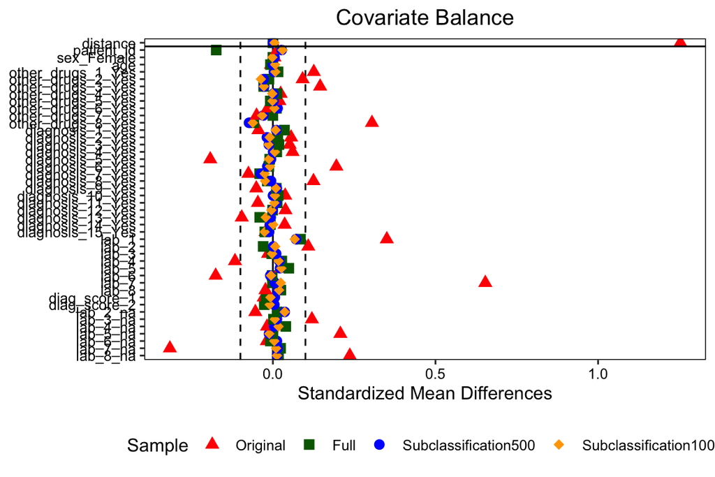

```r
love.plot(psm_full, stats = c("m"),  abs = FALSE,
          weights = list(sub500 = psm_sub500,
                         sub1000 = psm_sub1000),
          drop.distance = FALSE, thresholds = 0.1,
          binary = "std",
          shapes = c("triangle", "square", "circle", "diamond"),
          colors = c("red", "darkgreen", "blue", "orange"),
          sample.names = c("Original", "Full","Subclassification500", "Subclassification1000"),
          position = "bottom")
```

#### Effect estimation after matching

```r
# annotation to survival curve
surv_annotate <- function(surv_plot, cox_fit, ...) {

  # extract p-value for survival curve plotting
  cox_pval <-  function(cox_fit) {
    format(round(tail(summary(cox_fit)$coefficient[1,], 1), digits = 3), nsmall = 3)
  }

  # extract HR and 95%CI for plotting
  cox_hr <- function(cox_fit) {
    paste0(format(round(summary(cox_fit)$conf.int[1, 1], digits = 2), nsmall = 2),
           " [", format(round(summary(cox_fit)$conf.int[1, 3], digits = 2), nsmall = 2), ", ",
           format(round(summary(cox_fit)$conf.int[1, 4], digits = 2), nsmall = 2), "]")
  }

  # annotate on the plot
  annotation_text <- data.frame(
    x = c(1, 1),
    y = c(0.1, 0.05),
    label = c(paste0("HR = ", cox_hr(cox_fit)),
              paste0("P = ", cox_pval(cox_fit)))
  )

  surv_plot$plot <- surv_plot$plot +
    geom_text(data = annotation_text,
              aes(x = x, y = y, label = label),
              ...)

  return(surv_plot)
}



# survival curve plot

surv_plot <- function(cox_fit, surv_fit, data, ...) {
  survplot <- survminer::ggsurvplot(surv_fit, data = data,
                                    fun = "event", censor = FALSE, surv.scale = "percent",
                                    legend.title = "Medication", legend.labs = levels(event_time$treatment_variable),
                                    xlab = "Month", xscale = "y_m",
                                    ylab = "Cummulative bleeding events (%)",
                                    ...)

  survplot$plot <- survplot$plot +
    scale_y_continuous(labels = ~paste0(.x * 100, "%")) +
    theme(legend.position = c(0.9, 0.2),
          legend.background = element_rect(size = 0.5, linetype = "solid", color = "black"))

  return(survplot)
}
```

##### Cox regression with raw data

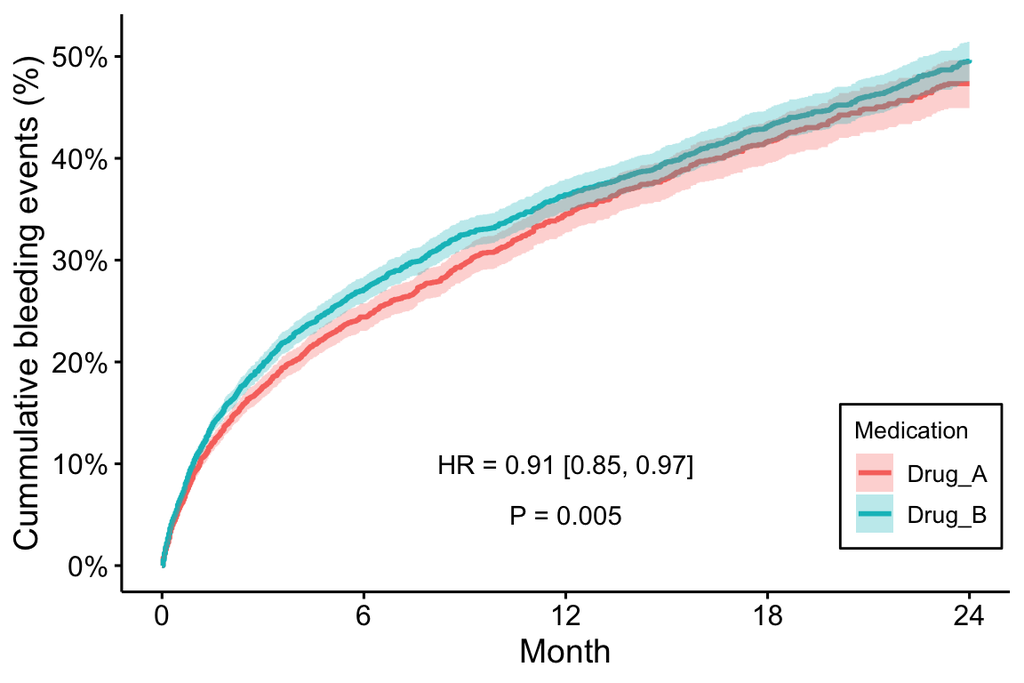

```r
cox_raw <-
  event_time %>%
  mutate(treatment_variable = relevel(treatment_variable, ref = 2)) %>%
  coxph(Surv(duration_in_years, bleeding_event_1_event_0_censored) ~ treatment_variable, data = .)

surv_raw <- survfit(Surv(duration_in_years, bleeding_event_1_event_0_censored) ~ treatment_variable, data = event_time)

plot_raw <- surv_plot(cox_raw, surv_raw, event_time, conf.int = TRUE)

surv_annotate(plot_raw, cox_raw)
```

Looks like drugA is statistically lower in bleeding events than drugB, particularly in the 1st year after use.

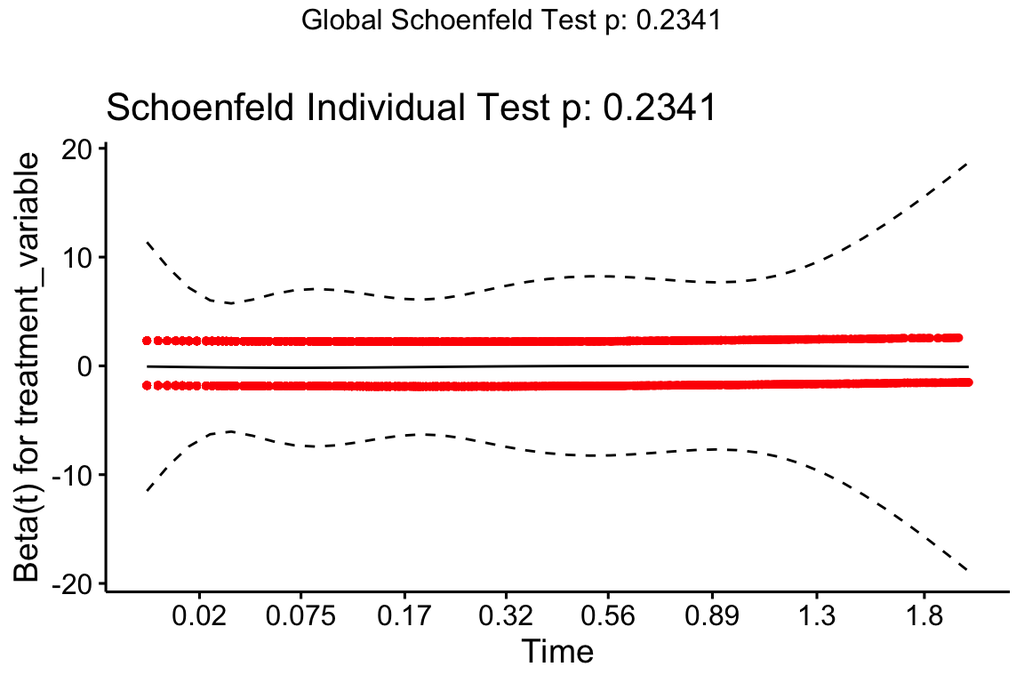

```r
ggcoxzph(cox.zph(cox_raw))
```

Proportional hazard assumption test passed.

##### Optimal full mathching

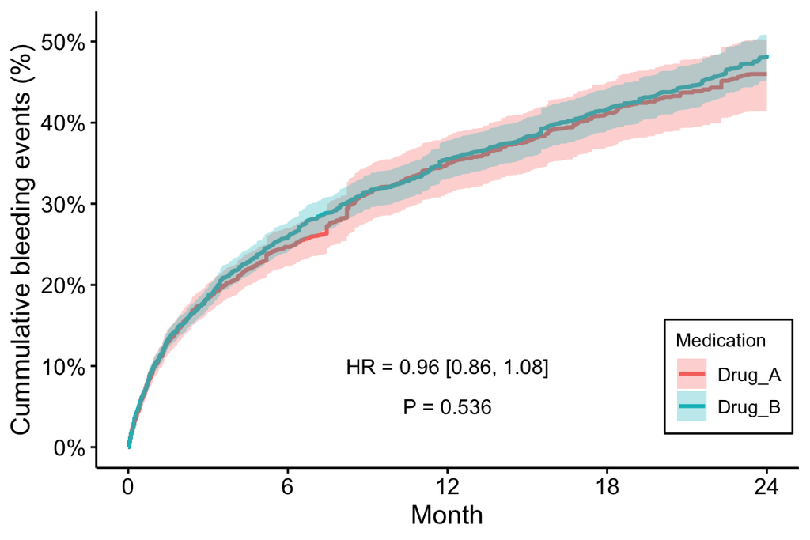

```r
dat_full <- match.data(psm_full) %>%
  left_join(event_time, by = c("patient_id", "treatment_variable"))



cox_full <-
  dat_full %>%
  mutate(treatment_variable = relevel(treatment_variable, ref = 2)) %>%
  survival::coxph(Surv(duration_in_years, bleeding_event_1_event_0_censored) ~ treatment_variable,
                  data = ., weights = weights, cluster = subclass, robust = TRUE)

surv_full <- survival::survfit(Surv(duration_in_years, bleeding_event_1_event_0_censored) ~ treatment_variable,
                               data = dat_full, weights = weights, cluster = subclass, robust = TRUE)


plot_full <- surv_plot(cox_full, surv_full, dat_full, conf.int = TRUE)

surv_annotate(plot_full, cox_full)
```

The difference between DrugA and DrugB is not significant after full matching.

##### Subclassification

###### 500 subclass

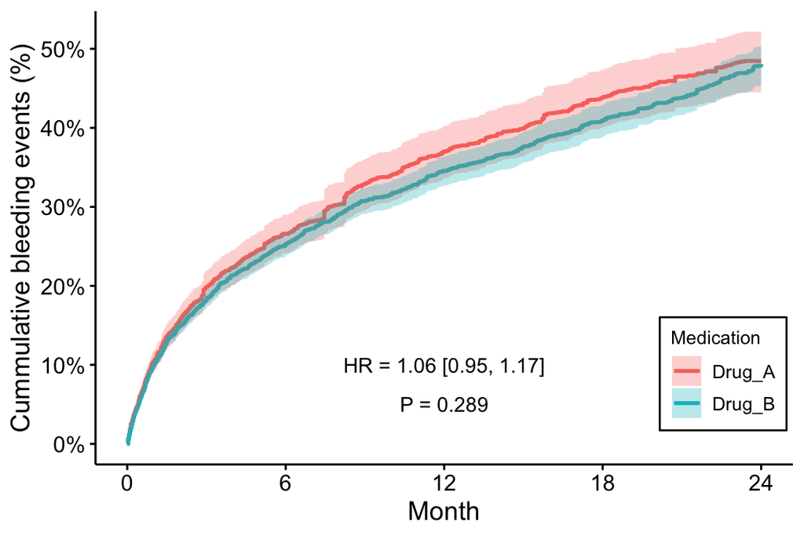

```r
dat_sub500 <- match.data(psm_sub500) %>%
  left_join(event_time, by = c("patient_id", "treatment_variable"))


cox_sub500 <-
  dat_sub500 %>%
  mutate(treatment_variable = relevel(treatment_variable, ref = 2)) %>%
  survival::coxph(Surv(duration_in_years, bleeding_event_1_event_0_censored) ~ treatment_variable,
                              data = ., weights = weights, cluster = subclass, robust = TRUE)

surv_sub500 <- survival::survfit(Surv(duration_in_years, bleeding_event_1_event_0_censored) ~ treatment_variable,
                              data = dat_sub500, weights = weights, cluster = subclass, robust = TRUE)


plot_sub500 <- surv_plot(cox_sub500, surv_sub500, dat_sub500, conf.int = TRUE)

surv_annotate(plot_sub500, cox_sub500)
```

###### 1000 subclass

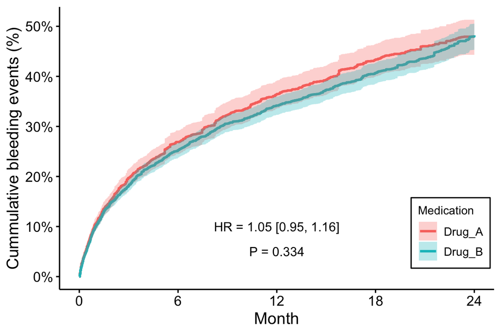

```r
dat_sub1000 <- match.data(psm_sub1000) %>%
  left_join(event_time, by = c("patient_id", "treatment_variable"))


cox_sub1000 <-
  dat_sub1000 %>%
  mutate(treatment_variable = relevel(treatment_variable, ref = 2)) %>%
  survival::coxph(Surv(duration_in_years, bleeding_event_1_event_0_censored) ~ treatment_variable,
                              data = ., weights = weights, cluster = subclass, robust = TRUE)

surv_sub1000 <- survival::survfit(Surv(duration_in_years, bleeding_event_1_event_0_censored) ~ treatment_variable,
                              data = dat_sub1000, weights = weights, cluster = subclass, robust = TRUE)


plot_sub1000 <- surv_plot(cox_sub1000, surv_sub1000, dat_sub1000, conf.int = TRUE)

surv_annotate(plot_sub1000, cox_sub1000)
```

The difference between DrugA and DrugB is not significant after subclassification.

#### Sensitivity analysis

##### Conventional multivariable cox regression

```r
dat_merge <- pt_char_psm%>%
  left_join(event_time, by = c("patient_id", "treatment_variable"))

cox_cond <- dat_merge %>%
  mutate(treatment_variable = relevel(treatment_variable, ref = 2)) %>%
  coxph(Surv(duration_in_years, bleeding_event_1_event_0_censored) ~ . -patient_id, data = .)

summary(cox_cond)
```

```
Call:
coxph(formula = Surv(duration_in_years, bleeding_event_1_event_0_censored) ~
    . - patient_id, data = .)

  n= 19284, number of events= 3577

                               coef  exp(coef)   se(coef)      z Pr(>|z|)
treatment_variableDrug_A  5.125e-02  1.053e+00  3.691e-02  1.389 0.164984
sexFemale                -1.974e-03  9.980e-01  3.400e-02 -0.058 0.953695
age                       3.482e-03  1.003e+00  1.568e-03  2.221 0.026339 *
other_drugs_1Yes          3.323e-02  1.034e+00  4.089e-02  0.813 0.416397
other_drugs_2Yes          2.043e-01  1.227e+00  4.594e-02  4.446 8.75e-06 ***
other_drugs_3Yes          1.691e-01  1.184e+00  3.612e-02  4.682 2.83e-06 ***
other_drugs_4Yes         -1.541e-02  9.847e-01  4.396e-02 -0.351 0.725843
other_drugs_5Yes          4.823e-02  1.049e+00  9.729e-02  0.496 0.620086
other_drugs_6Yes          4.021e-02  1.041e+00  4.744e-02  0.848 0.396685
other_drugs_7Yes         -4.260e-02  9.583e-01  3.646e-02 -1.168 0.242608
other_drugs_8Yes          1.056e-01  1.111e+00  4.131e-02  2.557 0.010559 *
diagnosis_1Yes           -1.152e-01  8.912e-01  4.277e-02 -2.695 0.007045 **
diagnosis_2Yes            6.957e-02  1.072e+00  4.306e-02  1.616 0.106176
diagnosis_3Yes            1.125e-01  1.119e+00  6.498e-02  1.732 0.083273 .
diagnosis_4Yes           -5.536e-01  5.749e-01  2.009e-01 -2.755 0.005863 **
diagnosis_5Yes           -8.271e-02  9.206e-01  6.871e-02 -1.204 0.228722
diagnosis_6Yes            1.899e-01  1.209e+00  5.744e-02  3.306 0.000945 ***
diagnosis_7Yes            9.529e-02  1.100e+00  4.881e-02  1.952 0.050920 .
diagnosis_8Yes           -9.273e-02  9.114e-01  4.208e-02 -2.204 0.027540 *
diagnosis_9Yes           -8.807e-02  9.157e-01  4.480e-02 -1.966 0.049282 *
diagnosis_10Yes           2.862e-01  1.331e+00  3.972e-02  7.206 5.77e-13 ***
diagnosis_11Yes           1.340e-01  1.143e+00  8.054e-02  1.663 0.096232 .
diagnosis_12Yes           1.217e+00  3.376e+00  5.149e-02 23.632  < 2e-16 ***
diagnosis_13Yes          -1.893e-01  8.275e-01  5.961e-02 -3.176 0.001495 **
diagnosis_14Yes           3.726e-01  1.452e+00  4.553e-02  8.183 2.76e-16 ***
diagnosis_15Yes          -1.652e-01  8.477e-01  1.525e-01 -1.084 0.278538
lab_1                     7.247e-02  1.075e+00  1.749e-02  4.143 3.43e-05 ***
lab_2                     3.599e-04  1.000e+00  2.291e-04  1.571 0.116118
lab_3                     1.836e-05  1.000e+00  1.300e-03  0.014 0.988728
lab_4                    -5.452e-02  9.469e-01  4.484e-02 -1.216 0.224092
lab_5                    -6.728e-03  9.933e-01  2.231e-02 -0.301 0.763036
lab_6                     4.450e-04  1.000e+00  1.291e-03  0.345 0.730285
lab_7                     6.363e-02  1.066e+00  1.628e-02  3.908 9.32e-05 ***
```

[output cut: 47 more lines]

```
lab_8                       0.9999     1.0001    0.9993    1.0004
diag_score_1                1.0977     0.9110    1.0527    1.1446
diag_score_2                1.0624     0.9413    1.0249    1.1012
lab_2_naTRUE                0.8125     1.2307    0.7532    0.8766
lab_3_naTRUE                0.9171     1.0904    0.8049    1.0450
lab_4_naTRUE                1.0180     0.9823    0.9137    1.1343
lab_5_naTRUE                0.9409     1.0628    0.8700    1.0175
lab_6_naTRUE                1.0624     0.9412    0.7938    1.4220
lab_7_naTRUE                0.9058     1.1041    0.8245    0.9950
lab_8_naTRUE                1.2282     0.8142    1.1338    1.3305

Concordance= 0.655  (se = 0.005 )
Likelihood ratio test= 1096  on 43 df,   p=<2e-16
Wald test            = 1331  on 43 df,   p=<2e-16
Score (logrank) test = 1463  on 43 df,   p=<2e-16
```

##### Forest plot for sensitivity analysis

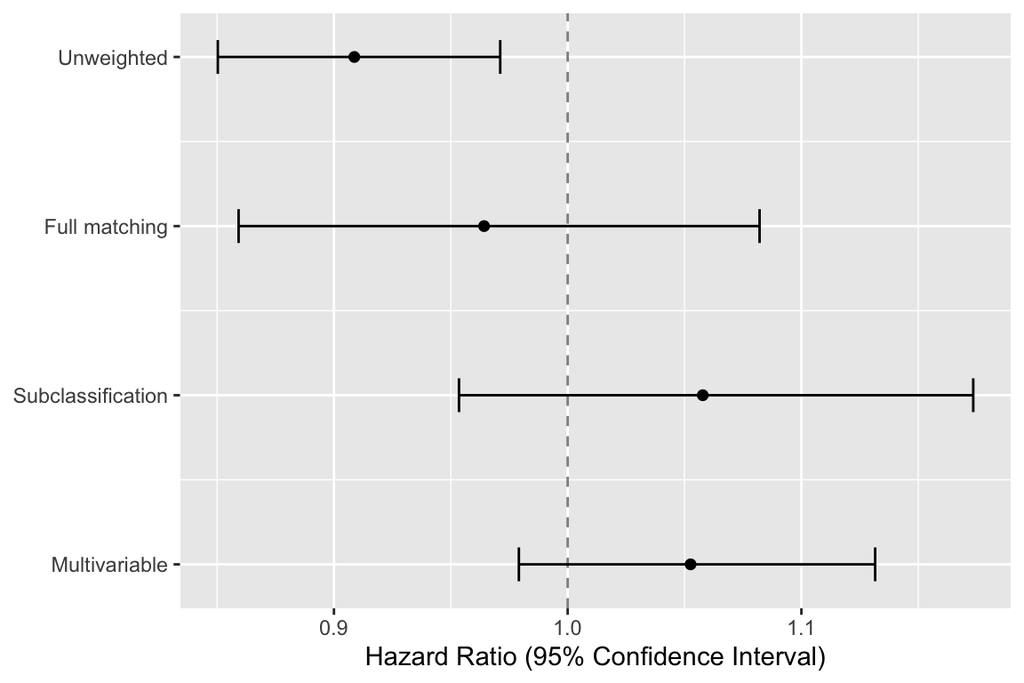

```r
# collect results

res_sum <- summary(cox_raw)$conf.int[1, c(1, 3, 4)] %>%
  bind_rows(summary(cox_full)$conf.int[1, c(1, 3, 4)]) %>%
  bind_rows(summary(cox_sub500)$conf.int[1, c(1, 3, 4)]) %>%
  bind_rows(summary(cox_cond)$conf.int[1, c(1, 3, 4)]) %>%
  rename(hr = "exp(coef)",
         ll = "lower .95",
         ul = "upper .95") %>%
  mutate(index = 1:4,
         model = c("Unweighted", "Full matching", "Subclassification", "Multivariable"))

forest_plot <-
  res_sum %>%
  ggplot(aes(y = index, x = hr, xmin = ll, xmax = ul)) +
  geom_point(aes(shape = "solid circle"), size = 2) +
  # scale_shape_manual(values = c(4, 18, 20, 17)) +
  geom_errorbar(width = .2) +
  geom_vline(xintercept = 1, linetype = 2, alpha = .5) +
  scale_y_continuous(name = NULL,
                     breaks = res_sum$index,
                     labels = res_sum$model,
                     trans="reverse") +
    xlab("Hazard Ratio (95% Confidence Interval)") +
    theme(legend.position = "none")


forest_plot
```

#### Subgroup analysis

```r
dat_full_subgroup <- dat_full %>%
  mutate(age_group = cut(age, breaks = c(0, 60, 200), right = FALSE, labels = c("Adult", "Elderly")))

# Test for subgroup balance just in case they are not
dat_full_subgroup %>%
  bal.tab(treatment_variable ~ sex + age_group + sex*age_group, data = .)
```

```
Balance Measures
                                 Type Diff.Un
sex_Female                     Binary  0.0022
age_group_Elderly              Binary -0.0040
sex_Male * age_group_Adult     Binary  0.0026
sex_Female * age_group_Adult   Binary  0.0015
sex_Male * age_group_Elderly   Binary -0.0048
sex_Female * age_group_Elderly Binary  0.0008

Sample sizes
    Drug_A Drug_B
All   8518  10766
```

##### Sex

```r
# Full matching
cox_full_sex <- coxph(Surv(duration_in_years, bleeding_event_1_event_0_censored) ~ relevel(treatment_variable, ref = 2) * sex,
                              data = dat_full_subgroup, weights = weights, cluster = subclass, robust = TRUE)

summary(cox_full_sex)
```

```
Call:
coxph(formula = Surv(duration_in_years, bleeding_event_1_event_0_censored) ~
    relevel(treatment_variable, ref = 2) * sex, data = dat_full_subgroup,
    weights = weights, robust = TRUE, cluster = subclass)

  n= 19284, number of events= 3577

                                                         coef exp(coef)
relevel(treatment_variable, ref = 2)Drug_A           -0.01910   0.98108
sexFemale                                             0.06485   1.06700
relevel(treatment_variable, ref = 2)Drug_A:sexFemale -0.04117   0.95967
                                                     se(coef) robust se      z
relevel(treatment_variable, ref = 2)Drug_A            0.04482   0.07819 -0.244
sexFemale                                             0.04463   0.06680  0.971
relevel(treatment_variable, ref = 2)Drug_A:sexFemale  0.06928   0.11846 -0.348
                                                     Pr(>|z|)
relevel(treatment_variable, ref = 2)Drug_A              0.807
sexFemale                                               0.332
relevel(treatment_variable, ref = 2)Drug_A:sexFemale    0.728

                                                     exp(coef) exp(-coef)
relevel(treatment_variable, ref = 2)Drug_A              0.9811     1.0193
sexFemale                                               1.0670     0.9372
relevel(treatment_variable, ref = 2)Drug_A:sexFemale    0.9597     1.0420
                                                     lower .95 upper .95
relevel(treatment_variable, ref = 2)Drug_A              0.8417     1.144
sexFemale                                               0.9361     1.216
relevel(treatment_variable, ref = 2)Drug_A:sexFemale    0.7608     1.210

Concordance= 0.511  (se = 0.009 )
Likelihood ratio test= 3.44  on 3 df,   p=0.3
Wald test            = 1.42  on 3 df,   p=0.7
Score (logrank) test = 3.47  on 3 df,   p=0.3,   Robust = 1.39  p=0.7

  (Note: the likelihood ratio and score tests assume independence of
     observations within a cluster, the Wald and robust score tests do not).
```

No interaction between treatment and sex.

##### Age group (life stage)

```r
# Full matching
cox_full_age <- coxph(Surv(duration_in_years, bleeding_event_1_event_0_censored) ~ relevel(treatment_variable, ref = 2) * age_group,
                      data = dat_full_subgroup,
                      weights = weights, cluster = subclass, robust = TRUE)

summary(cox_full_age)
```

```
Call:
coxph(formula = Surv(duration_in_years, bleeding_event_1_event_0_censored) ~
    relevel(treatment_variable, ref = 2) * age_group, data = dat_full_subgroup,
    weights = weights, robust = TRUE, cluster = subclass)

  n= 19284, number of events= 3577

                                                                coef exp(coef)
relevel(treatment_variable, ref = 2)Drug_A                  -0.22369   0.79956
age_groupElderly                                             0.03030   1.03076
relevel(treatment_variable, ref = 2)Drug_A:age_groupElderly  0.19948   1.22077
                                                            se(coef) robust se
relevel(treatment_variable, ref = 2)Drug_A                   0.14122   0.20750
age_groupElderly                                             0.09043   0.12827
relevel(treatment_variable, ref = 2)Drug_A:age_groupElderly  0.14554   0.21491
                                                                 z Pr(>|z|)
relevel(treatment_variable, ref = 2)Drug_A                  -1.078    0.281
age_groupElderly                                             0.236    0.813
relevel(treatment_variable, ref = 2)Drug_A:age_groupElderly  0.928    0.353

                                                            exp(coef)
relevel(treatment_variable, ref = 2)Drug_A                     0.7996
age_groupElderly                                               1.0308
relevel(treatment_variable, ref = 2)Drug_A:age_groupElderly    1.2208
                                                            exp(-coef)
relevel(treatment_variable, ref = 2)Drug_A                      1.2507
age_groupElderly                                                0.9702
relevel(treatment_variable, ref = 2)Drug_A:age_groupElderly     0.8192
                                                            lower .95 upper .95
relevel(treatment_variable, ref = 2)Drug_A                     0.5324     1.201
age_groupElderly                                               0.8016     1.325
relevel(treatment_variable, ref = 2)Drug_A:age_groupElderly    0.8011     1.860

Concordance= 0.506  (se = 0.008 )
Likelihood ratio test= 5.6  on 3 df,   p=0.1
Wald test            = 2.22  on 3 df,   p=0.5
Score (logrank) test = 5.24  on 3 df,   p=0.2,   Robust = 2.24  p=0.5

  (Note: the likelihood ratio and score tests assume independence of
     observations within a cluster, the Wald and robust score tests do not).
```

No interaction between treatment and age group.

##### Plot subgroup analysis

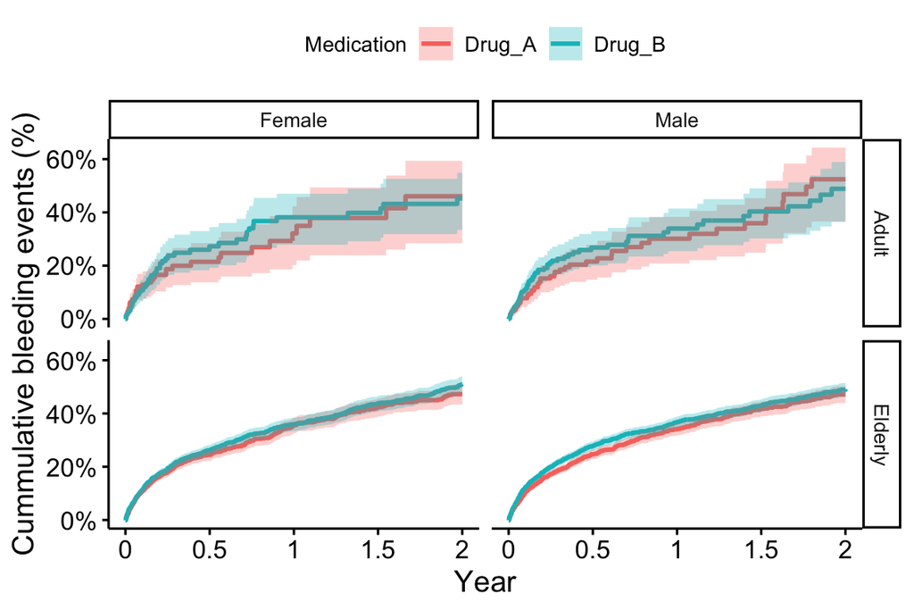

```r
plot_subgroup <-
  ggsurvplot_facet(cox_full, data = dat_full_subgroup, facet.by = c("age_group", "sex"),
                 fun = "event", censor = FALSE, surv.scale = "percent", conf.int = TRUE,
                 legend.title = "Medication",
                 legend.labs = levels(dat_full_subgroup$treatment_variable),
                 xlab = "Year",
                 ylab = "Cummulative bleeding events (%)",
                 short.panel.labs = TRUE
)

plot_subgroup
```

#### Save analysis results

```r
save.image(here("Data", "results.RData"))

print(Sys.info())
```

```
                                                                                            sysname
                                                                                           "Darwin"
                                                                                            release
                                                                                           "21.3.0"
                                                                                            version
"Darwin Kernel Version 21.3.0: Wed Jan  5 21:37:58 PST 2022; root:xnu-8019.80.24~20/RELEASE_X86_64"
                                                                                           nodename
                                                                                     "Jasons-MBP-2"
                                                                                            machine
                                                                                           "x86_64"
                                                                                              login
                                                                                             "root"
                                                                                               user
                                                                                         "jasonjin"
                                                                                     effective_user
                                                                                         "jasonjin"
```